# AlphaGenome motif-importance analysis

EVN, SVN, and EVS | held-out chr2 | real genomic backgrounds

# 1 Scope

This report summarizes motif-level interpretation of the final AlphaGenome models trained through chrX. Attribution is calculated across every held-out chr2 test sequence. Region selection uses Tangermeme recursive variable-length seqlet calling. The 3,000 strongest regions are selected with equal representation from the four combinations of class label and attribution sign (750 regions per stratum). Each selected region is compared with four class- and length-matched control windows and evaluated with 20 dinucleotide-shuffle ablations.

HOCOMOCO v14 CORE clustered motifs provide non-redundant labels. Motif labels are the closest TOMTOM matches to attributed regions; they are model-based annotations and do not establish transcription-factor occupancy in vivo.

# 2 Quality control

Analysis and attribution quality control

| Task | Classification | Test sequences | AUROC | Average precision | Attribution method | DeepLIFT relative error | Candidates tested | Important regions | ISM median correlation | ISM correlations below 0.5 |
| --- | --- | --- | --- | --- | --- | --- | --- | --- | --- | --- |
| EVN | Enhancer versus genomic background | 33,260 | 0.907 | 0.910 | saliency | 5.013 | 3,000 | 923 | 0.833 | 1 |
| SVN | Silencer versus genomic background | 28,258 | 0.903 | 0.905 | saliency | 4.124 | 3,000 | 806 | 0.833 | 1 |
| EVS | Enhancer versus silencer | 28,582 | 0.648 | 0.630 | saliency | 5.812 | 3,000 | 381 | 0.773 | 3 |

DeepLIFT failed its summation-to-delta audit for all three AlphaGenome classifiers because the backbone contains operations without valid DeepLIFT rules. The workflow therefore selected saliency automatically. Prediction parity between the wrapped and native model was exact for every task.

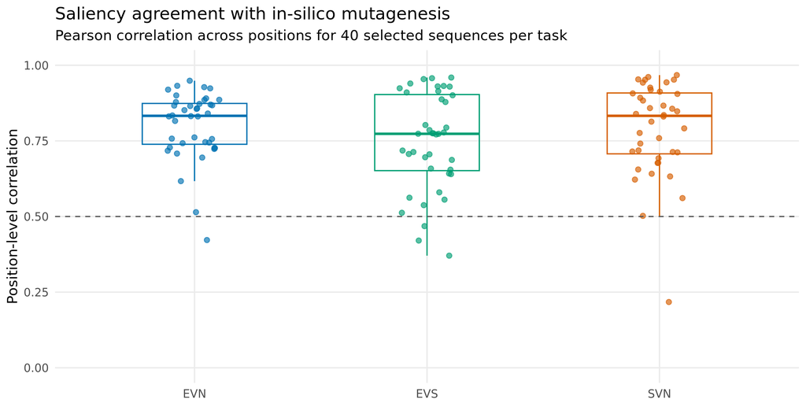

# 3 Candidate design

Balanced candidate panel

| Class | Attribution sign | Regions |
| --- | --- | --- |
| EVN |  |  |
| Negative class | negative | 750 |
| Negative class | positive | 750 |
| Positive class | negative | 750 |
| Positive class | positive | 750 |
| EVS |  |  |
| Negative class | negative | 750 |
| Negative class | positive | 750 |
| Positive class | negative | 750 |
| Positive class | positive | 750 |
| SVN |  |  |
| Negative class | negative | 750 |
| Negative class | positive | 750 |
| Positive class | negative | 750 |
| Positive class | positive | 750 |

All test sequences contribute to the attribution screen. The candidate cap restricts only the expensive perturbation analysis. Consequently, absence from the following tables means “not detected among the strongest tested regions,” not that a model never uses the motif.

# 4 Motif prevalence across all attributed regions

Twenty most frequently matched HOCOMOCO clusters per task

Counts use every annotated recursive seqlet, before ablation selection

| Motif | Regions | Sequences | Median attribution | Attribution Q25 | Attribution Q75 |
| --- | --- | --- | --- | --- | --- |
| EVN |  |  |  |  |  |
| ZNF649 | 3,051 | 2,808 | −1.61 | −2.03 | 3.80 |
| SNAI1 | 2,468 | 2,351 | −1.77 | −2.24 | −1.56 |
| ZNF410 | 2,068 | 1,949 | −1.68 | −2.30 | −1.50 |
| FOSL2 | 1,799 | 1,680 | 10.38 | 6.79 | 16.17 |
| ZNF578 | 1,709 | 1,618 | −1.62 | −2.04 | 4.33 |
| ZBTB40 | 1,624 | 1,522 | −1.76 | −2.43 | 3.83 |
| MTF1 | 1,587 | 1,487 | 3.25 | −1.81 | 3.85 |
| GATA1 | 1,563 | 1,422 | 5.61 | 4.28 | 7.70 |
| TSHZ2 | 1,560 | 1,484 | −1.72 | −2.30 | 4.80 |
| ZNF90 | 1,477 | 1,402 | −1.55 | −1.97 | 6.19 |
| ZNF248 | 1,458 | 1,371 | 3.29 | −2.21 | 3.93 |
| BATF2 | 1,385 | 1,333 | 3.88 | 3.33 | 5.06 |
| ZFAT | 1,385 | 1,302 | 3.37 | −1.70 | 4.50 |
| ZNF362 | 1,344 | 1,262 | −1.78 | −2.61 | −1.53 |
| ONECUT2 | 1,320 | 1,262 | −1.81 | −2.48 | −1.52 |
| ZNF562 | 1,236 | 1,191 | 4.02 | −1.74 | 6.13 |
| ZNF606 | 1,193 | 1,128 | 3.65 | 3.27 | 4.67 |
| MNX1 | 1,139 | 1,087 | −1.56 | −1.81 | 3.42 |
| NFYC | 1,135 | 1,078 | −1.61 | −1.93 | 3.34 |
| ZNF254 | 1,131 | 1,078 | −1.82 | −2.85 | 5.48 |
| EVS |  |  |  |  |  |
| ZNF649 | 3,083 | 2,829 | 0.17 | −0.21 | 0.23 |
| ZNF410 | 2,498 | 2,317 | 0.17 | 0.15 | 0.23 |
| MTF1 | 2,218 | 2,086 | −0.20 | −0.25 | 0.16 |
| ZFAT | 2,188 | 2,046 | −0.19 | −0.25 | 0.17 |
| ZBTB40 | 2,013 | 1,893 | 0.20 | 0.16 | 0.26 |
| BATF2 | 1,994 | 1,915 | −0.19 | −0.25 | 0.17 |
| ZNF578 | 1,992 | 1,895 | −0.19 | −0.22 | 0.22 |
| SNAI1 | 1,771 | 1,708 | −0.18 | −0.22 | 0.17 |
| ZNF500 | 1,736 | 1,655 | 0.17 | 0.16 | 0.20 |
| ZNF90 | 1,632 | 1,550 | 0.17 | −0.19 | 0.27 |
| MSANTD4 | 1,600 | 1,528 | 0.18 | 0.16 | 0.23 |
| GATA1 | 1,565 | 1,448 | −0.28 | −0.41 | 0.20 |
| MNX1 | 1,494 | 1,421 | 0.17 | 0.16 | 0.20 |
| ZNF248 | 1,465 | 1,396 | 0.18 | 0.16 | 0.22 |
| DUX4 | 1,420 | 1,360 | −0.20 | −0.23 | 0.19 |
| ZNF771 | 1,380 | 1,346 | 0.17 | 0.16 | 0.22 |
| ZFTA | 1,369 | 1,295 | −0.20 | −0.24 | −0.18 |
| ZFP41 | 1,365 | 1,313 | 0.17 | −0.19 | 0.23 |
| ZNF146 | 1,363 | 1,307 | 0.23 | 0.20 | 0.31 |
| ZNF562 | 1,306 | 1,245 | 0.20 | −0.20 | 0.28 |
| SVN |  |  |  |  |  |
| ZNF649 | 2,258 | 2,057 | −1.70 | −2.22 | 4.59 |
| SNAI1 | 2,175 | 2,030 | −1.92 | −2.41 | −1.69 |
| ZNF410 | 1,490 | 1,413 | −1.82 | −2.31 | −1.62 |
| MTF1 | 1,381 | 1,303 | −1.66 | −2.02 | 4.06 |
| ZNF578 | 1,245 | 1,183 | −1.81 | −2.30 | 4.65 |
| TSHZ2 | 1,195 | 1,131 | −1.86 | −2.53 | 5.11 |
| FOSL2 | 1,194 | 1,123 | 10.39 | 6.84 | 14.62 |
| BATF2 | 1,181 | 1,121 | 4.16 | 3.57 | 5.72 |
| GATA1 | 1,123 | 1,011 | 6.24 | 4.64 | 9.03 |
| ZNF814 | 1,093 | 1,035 | −1.78 | −2.16 | 3.64 |
| ZNF562 | 1,090 | 1,028 | 4.06 | −2.15 | 6.37 |
| ZBTB40 | 1,081 | 1,027 | −1.77 | −2.47 | 4.40 |
| ZNF254 | 1,067 | 1,004 | −2.04 | −3.03 | 5.56 |
| ZNF248 | 1,059 | 1,015 | −1.73 | −2.54 | 4.07 |
| ZFAT | 1,044 | 994 | 3.57 | −1.93 | 4.58 |
| ZNF90 | 941 | 898 | 3.81 | −2.11 | 7.80 |
| ZNF606 | 926 | 872 | 3.95 | 3.54 | 5.34 |
| NFYC | 899 | 851 | −1.74 | −2.28 | 3.66 |
| ZFP41 | 887 | 841 | −1.73 | −2.16 | 4.23 |
| ONECUT2 | 865 | 827 | −1.81 | −2.43 | 3.58 |

This descriptive inventory is independent of the strongest-region ablation panel. A frequent cluster can therefore remain biologically interesting even when its individual regions have moderate attribution or are not represented among the strongest ablated sites.

# 5 Task-specific causal motif signals

## 5.1 EVN: enhancer versus genomic background

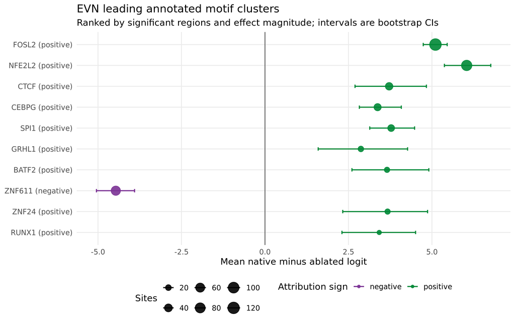

## 5.2 SVN: silencer versus genomic background

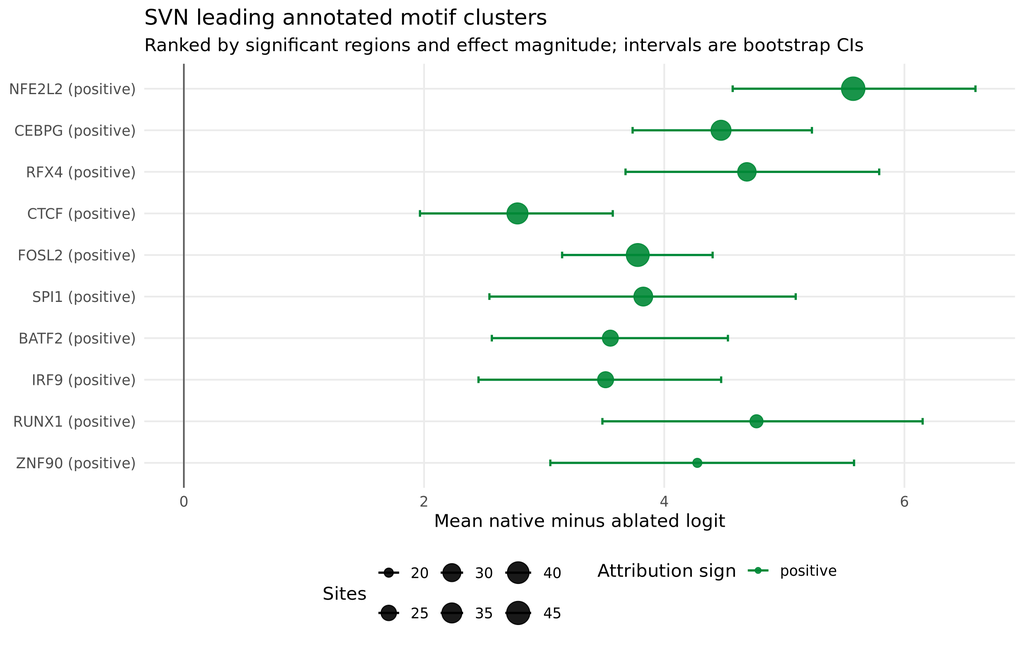

## 5.3 EVS: enhancer versus silencer

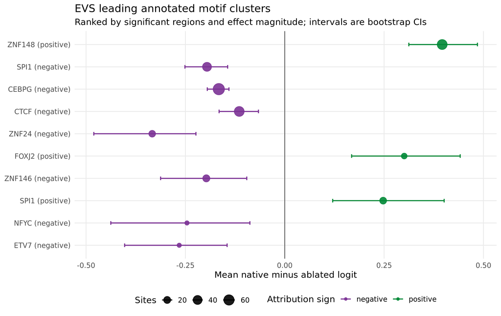

Leading motif clusters by causal-region support

| Motif | Sign | Sites | Important regions | Mean ablation effect | Bootstrap CI | Positive-class sequences | Negative-class sequences |
| --- | --- | --- | --- | --- | --- | --- | --- |
| EVN |  |  |  |  |  |  |  |
| FOSL2 | positive | 124 | 90 | 5.10 | [4.74, 5.46] | 91 | 33 |
| NFE2L2 | positive | 90 | 75 | 6.04 | [5.37, 6.76] | 78 | 12 |
| CTCF | positive | 36 | 23 | 3.72 | [2.70, 4.83] | 26 | 10 |
| CEBPG | positive | 32 | 17 | 3.37 | [2.83, 4.08] | 18 | 14 |
| SPI1 | positive | 28 | 16 | 3.78 | [3.14, 4.48] | 15 | 12 |
| GRHL1 | positive | 19 | 12 | 2.87 | [1.59, 4.27] | 14 | 5 |
| BATF2 | positive | 18 | 11 | 3.66 | [2.60, 4.91] | 12 | 6 |
| ZNF611 | negative | 65 | 9 | −4.47 | [-5.05, -3.90] | 9 | 49 |
| ZNF24 | positive | 18 | 9 | 3.67 | [2.33, 4.87] | 10 | 8 |
| RUNX1 | positive | 16 | 9 | 3.42 | [2.31, 4.51] | 9 | 7 |
| EVS |  |  |  |  |  |  |  |
| ZNF148 | positive | 54 | 28 | 0.40 | [0.31, 0.48] | 30 | 24 |
| SPI1 | negative | 40 | 11 | −0.20 | [-0.25, -0.14] | 18 | 21 |
| CEBPG | negative | 79 | 11 | −0.17 | [-0.19, -0.14] | 44 | 35 |
| CTCF | negative | 53 | 11 | −0.11 | [-0.17, -0.07] | 30 | 23 |
| ZNF24 | negative | 18 | 7 | −0.33 | [-0.48, -0.22] | 4 | 12 |
| FOXJ2 | positive | 13 | 6 | 0.30 | [0.17, 0.44] | 10 | 3 |
| ZNF146 | negative | 21 | 6 | −0.20 | [-0.31, -0.10] | 14 | 7 |
| SPI1 | positive | 19 | 5 | 0.25 | [0.12, 0.40] | 11 | 6 |
| NFYC | negative | 10 | 5 | −0.25 | [-0.44, -0.09] | 3 | 7 |
| ETV7 | negative | 10 | 4 | −0.27 | [-0.40, -0.15] | 3 | 7 |
| SVN |  |  |  |  |  |  |  |
| NFE2L2 | positive | 46 | 32 | 5.57 | [4.57, 6.59] | 37 | 9 |
| CEBPG | positive | 35 | 26 | 4.47 | [3.74, 5.23] | 30 | 5 |
| RFX4 | positive | 31 | 23 | 4.69 | [3.68, 5.79] | 25 | 6 |
| CTCF | positive | 38 | 21 | 2.78 | [1.97, 3.57] | 27 | 11 |
| FOSL2 | positive | 44 | 18 | 3.78 | [3.15, 4.40] | 23 | 21 |
| SPI1 | positive | 32 | 16 | 3.83 | [2.54, 5.09] | 17 | 15 |
| BATF2 | positive | 26 | 16 | 3.55 | [2.56, 4.53] | 17 | 9 |
| IRF9 | positive | 26 | 14 | 3.51 | [2.45, 4.47] | 16 | 10 |
| RUNX1 | positive | 22 | 13 | 4.77 | [3.49, 6.15] | 15 | 7 |
| ZNF90 | positive | 20 | 12 | 4.28 | [3.05, 5.58] | 13 | 7 |

# 6 Model-derived and reference motif logos

Each panel aligns the tested regions assigned to a motif and averages their signed nucleotide contributions after correcting for motif orientation. The paired HOCOMOCO PWM is the reference motif used for annotation. Individual sequence-level attribution logos remain available as quality-control artifacts but are omitted here.

## 6.1 EVN leading motif logos

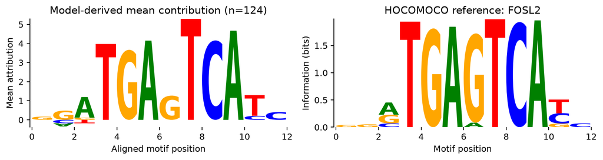

FOSL2 (positive); 124 tested sites, 90 important regions

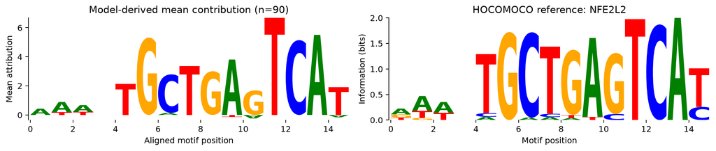

NFE2L2 (positive); 90 tested sites, 75 important regions

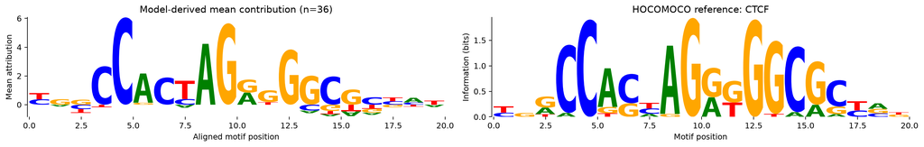

CTCF (positive); 36 tested sites, 23 important regions

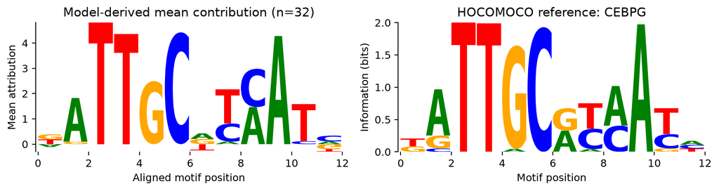

CEBPG (positive); 32 tested sites, 17 important regions

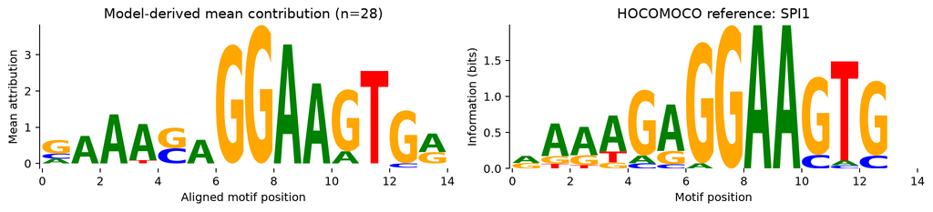

SPI1 (positive); 28 tested sites, 16 important regions

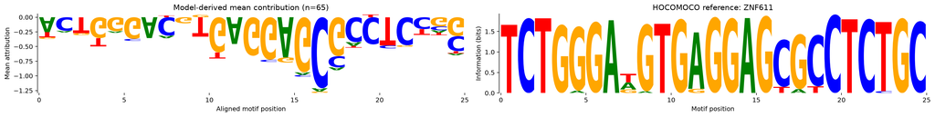

ZNF611 (negative); 65 tested sites, 9 important regions

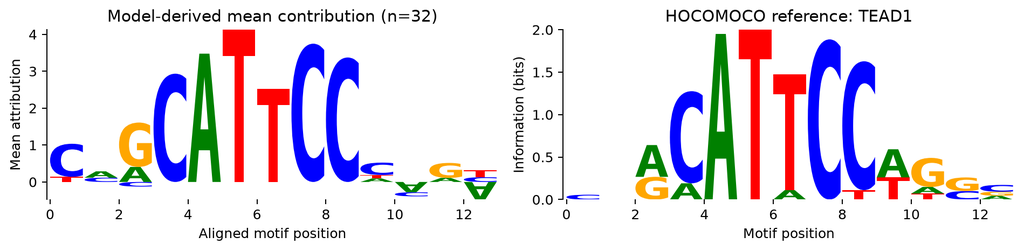

TEAD1 (positive); 32 tested sites, 8 important regions

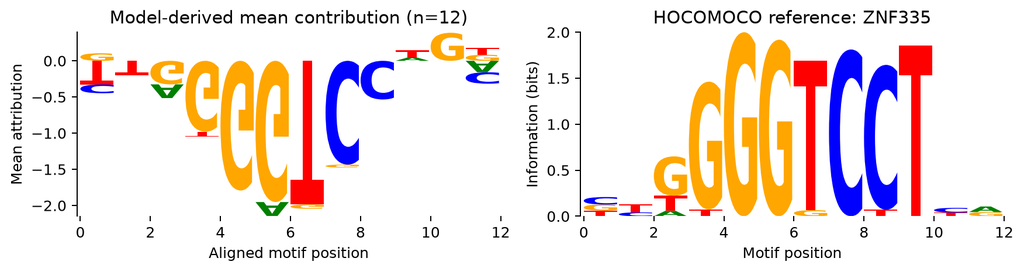

ZNF335 (negative); 12 tested sites, 6 important regions

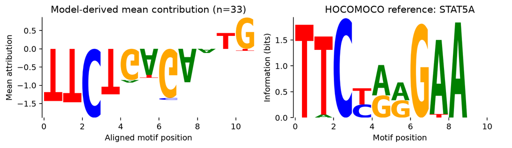

STAT5A (negative); 33 tested sites, 4 important regions

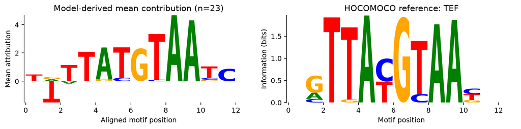

TEF (positive); 23 tested sites, 4 important regions

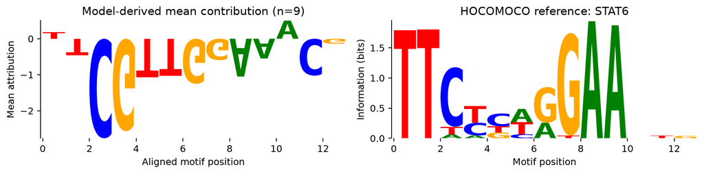

STAT6 (negative); 9 tested sites, 1 important regions

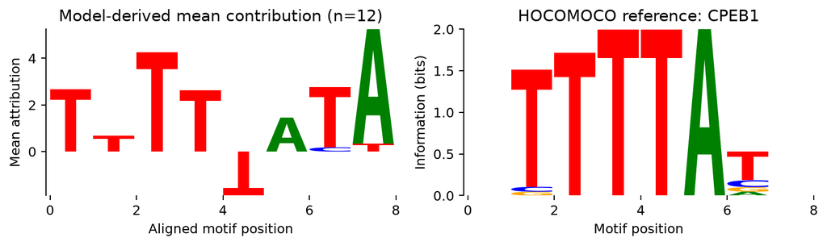

CPEB1 (positive); 12 tested sites, 1 important regions

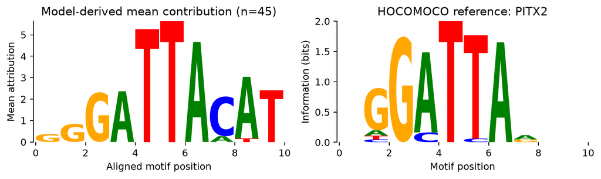

PITX2 (positive); 45 tested sites, 1 important regions

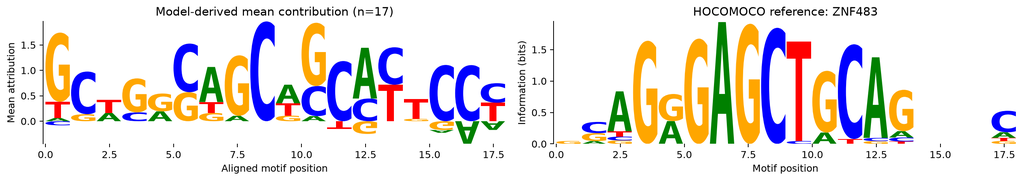

ZNF483 (positive); 17 tested sites, 1 important regions

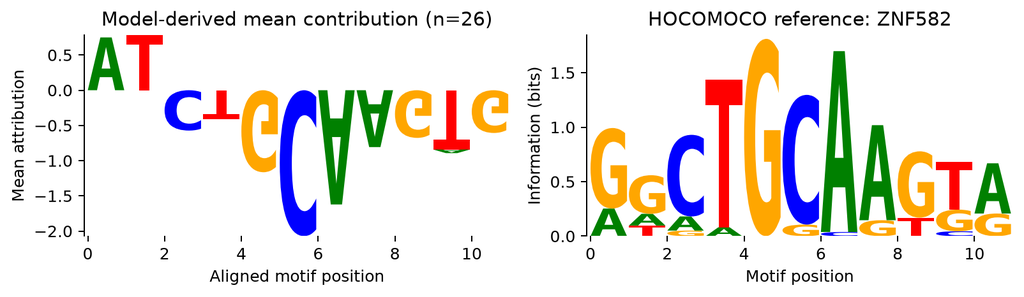

ZNF582 (negative); 26 tested sites, 0 important regions

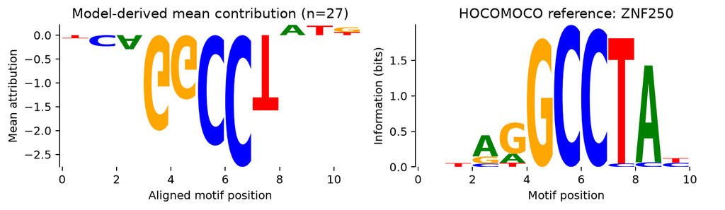

ZNF250 (negative); 27 tested sites, 0 important regions

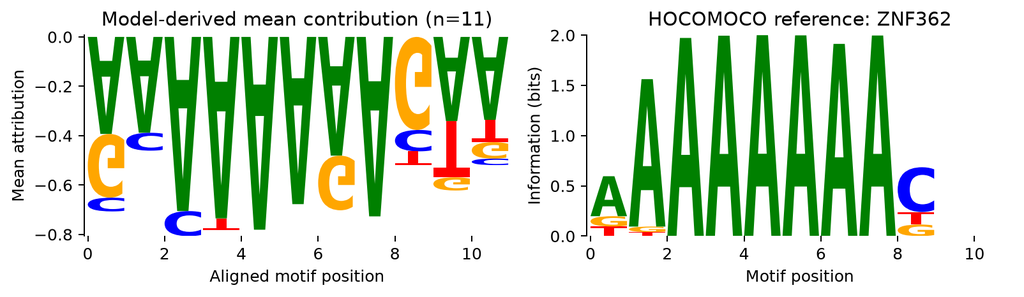

ZNF362 (negative); 11 tested sites, 0 important regions

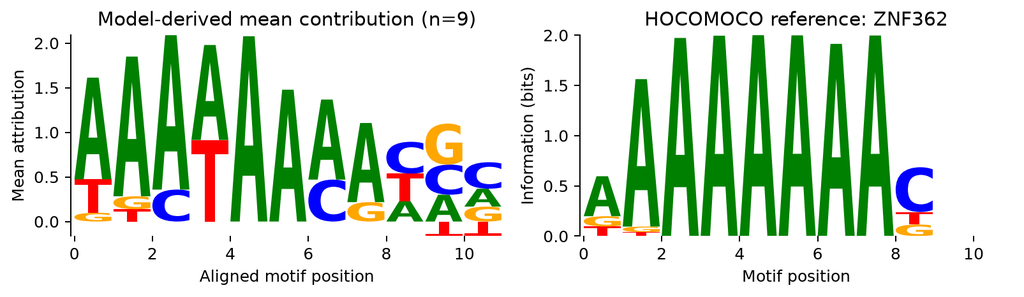

ZNF362 (positive); 9 tested sites, 0 important regions